# SUMMARY SESSION 6

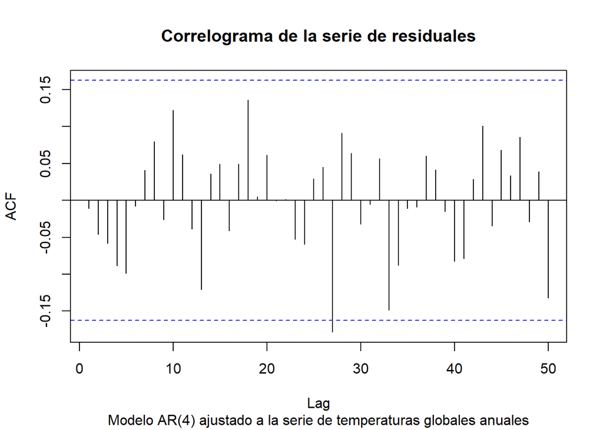

```r
acf(Global.ar$res[-(1:Global.ar$order)], lag = 50, main = "")
title(main = "Correlograma de la serie de residuales",
      sub = "Modelo AR(4) ajustado a la serie de temperaturas globales anuales")
```

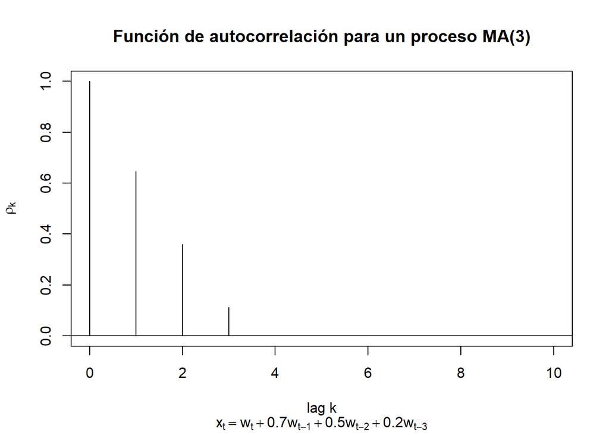

```r
####################################################################################################################################################

# Modelos MA(q)

# Ejemplos en R: Correlograma y Simulación

# Función en R para calcular la Función de Autocorrelación

rho <- function(k, beta){
  q <- length(beta) - 1
  if(k > q) ACF <- 0 else {
    s1 <- 0; s2 <- 0
    for(i in 1:(q-k+1)) s1 <- s1 + beta[i]*beta[i + k]
    for(i in 1:(q+1)) s2 <- s2 + beta[i]^2
    ACF <- s1/s2}
  ACF}

# Correlograma para un proceso MA(3)

beta <- c(1, 0.7, 0.5, 0.2)
rho.k <- rep(1, 10)
for(k in 1:10) rho.k[k] <- rho(k, beta)
plot(0:10, c(1, rho.k), ylab = expression(rho[k]), xlab = "lag k", type = "h",
     sub = expression(x[t] == w[t] + 0.7*w[t-1] + 0.5*w[t-2] + 0.2*w[t-3]),
     main = "Función de autocorrelación para un proceso MA(3)")
abline(0, 0)
```

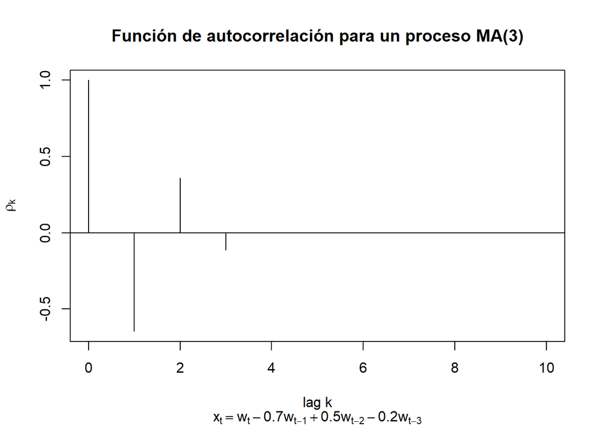

```r
# Correlograma para otro proceso MA(3)

beta <- c(1, -0.7, 0.5, -0.2)
rho.k <- rep(1, 10)
for(k in 1:10) rho.k[k] <- rho(k, beta)
plot(0:10, c(1, rho.k), ylab = expression(rho[k]), xlab = "lag k", type = "h",
     sub = expression(x[t] == w[t] - 0.7*w[t-1] + 0.5*w[t-2] - 0.2*w[t-3]),
     main = "Función de autocorrelación para un proceso MA(3)")
abline(0, 0)
```

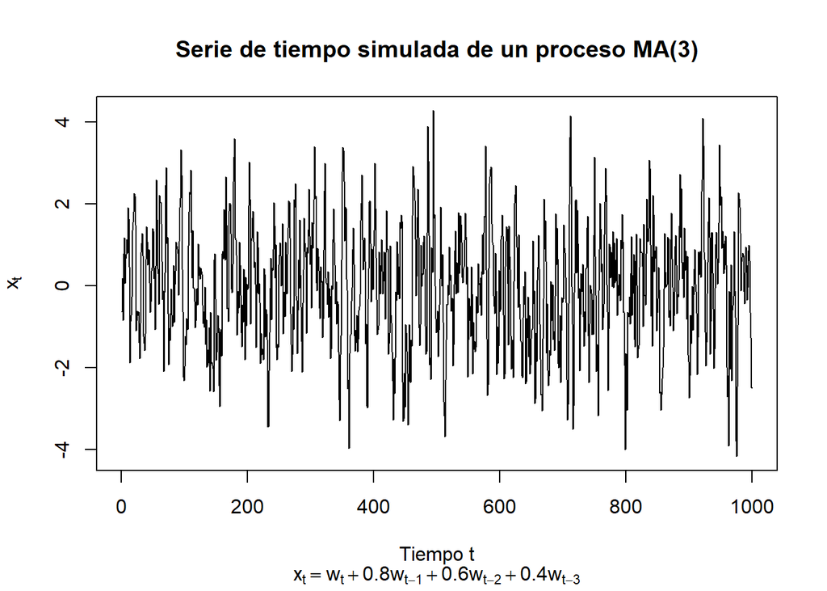

```r
####################################################################################################################################################

# Simulación de un proceso MA(3)

set.seed(1)
b <- c(0.8, 0.6, 0.4)
x <- w <- rnorm(1000)
for(t in 4:1000){
  for(j in 1:3) x[t] <- x[t] + b[j]*w[t-j]
}

plot(x, type = "l", ylab = expression(x[t]), xlab = "Tiempo t",
     sub = expression(x[t] == w[t] + 0.8*w[t-1] + 0.6*w[t-2] + 0.4*w[t-3]),
     main = "Serie de tiempo simulada de un proceso MA(3)")
```

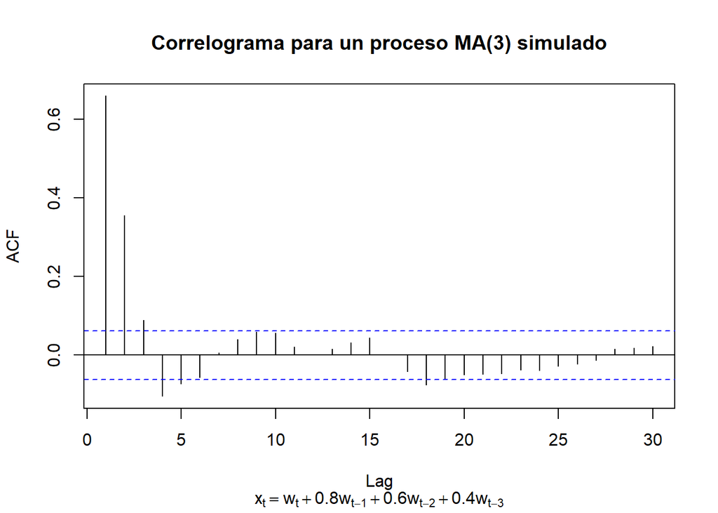

```r
###

acf(x, main = "")
title(main = "Correlograma para un proceso MA(3) simulado",
      sub = expression(x[t] == w[t] + 0.8*w[t-1] + 0.6*w[t-2] + 0.4*w[t-3]))
```

```r
####################################################################################################################################################

# Ajuste de modelos MA

x.ma <- arima(x, order = c(0, 0, 3))
x.ma
```

```
Call:
arima(x = x, order = c(0, 0, 3))

Coefficients:
         ma1     ma2     ma3  intercept
      0.7898  0.5665  0.3959    -0.0322
s.e.  0.0307  0.0351  0.0320     0.0898

sigma^2 estimated as 1.068:  log likelihood = -1452.41,  aic = 2912.83
```

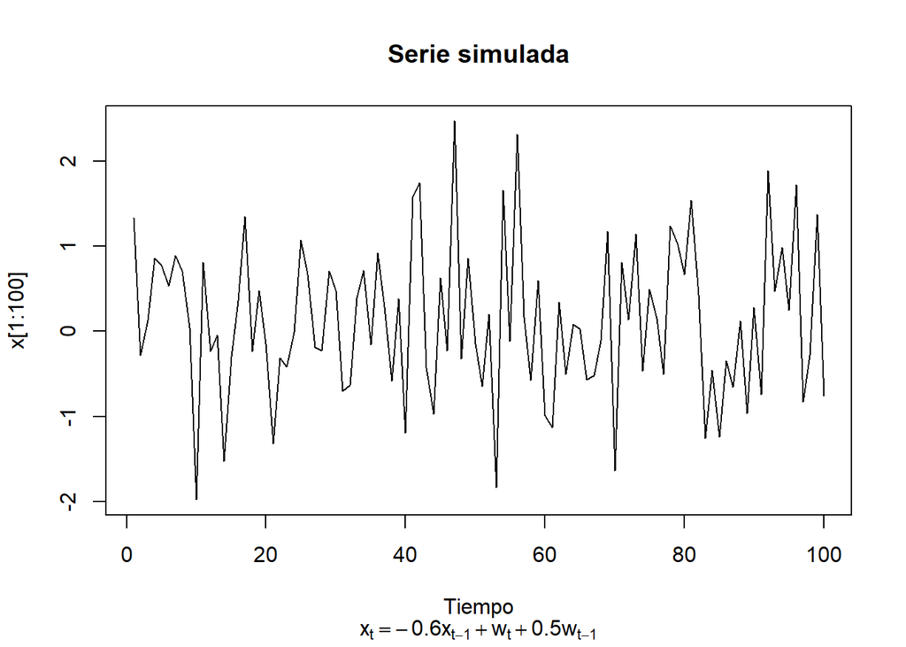

```r
####################################################################################################################################################

# Modelos ARMA(p, q)


# Simulación y Ajuste

set.seed(1)
x <- arima.sim(n = 10000, list(ar = -0.6, ma = 0.5))
plot(x[1:100], type = "l", xlab = "")
title(main = "Serie simulada", xlab = "Tiempo",
      sub = expression(x[t] == -0.6*x[t-1] + w[t] + 0.5*w[t-1]))
```

```r
#

coef(arima(x, order = c(1, 0, 1)))
```

```
         ar1          ma1    intercept
-0.596966371  0.502703368 -0.006571345
```

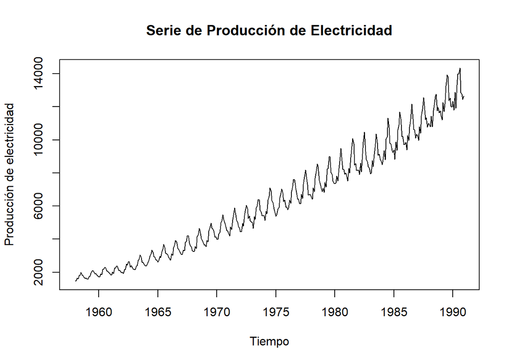

```r
#### Predicción

# Serie de producción de electricidad

CBE <- read.csv("cbe.csv", header = TRUE)
Elec.ts <- ts(CBE[, 3], start = 1958, freq = 12)
plot(Elec.ts, xlab = "", ylab = "")
title(main = "Serie de Producción de Electricidad",
      xlab = "Tiempo",
      ylab = "Producción de electricidad")
```

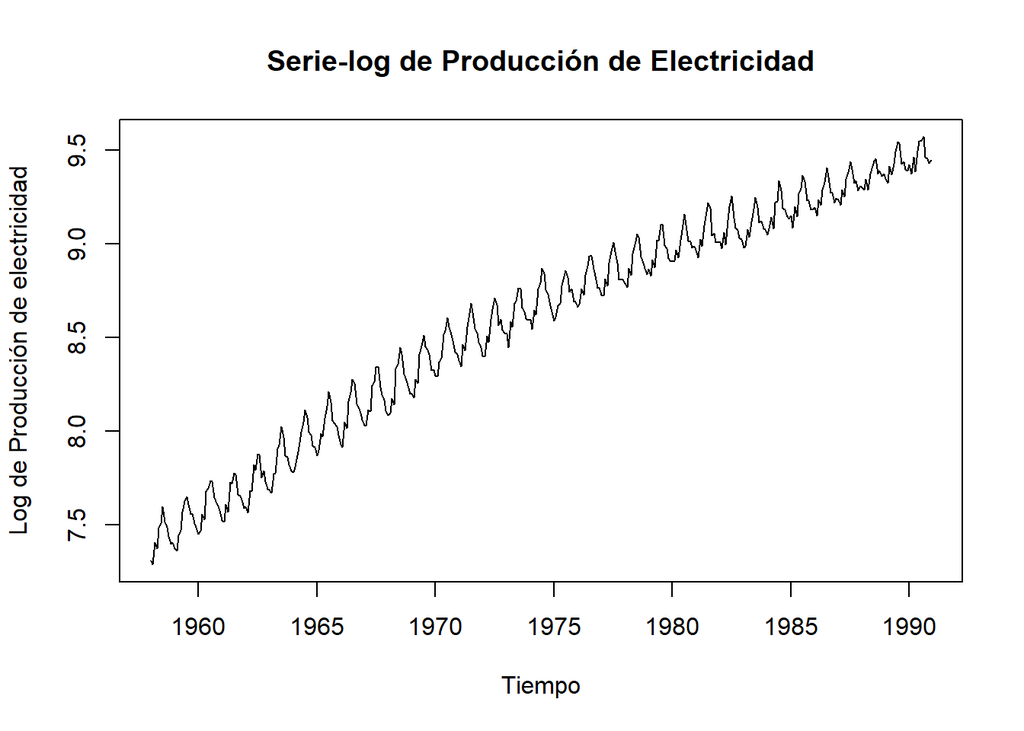

```r
#

plot(log(Elec.ts), xlab = "", ylab = "")
title(main = "Serie-log de Producción de Electricidad",
      xlab = "Tiempo",
      ylab = "Log de Producción de electricidad")
```

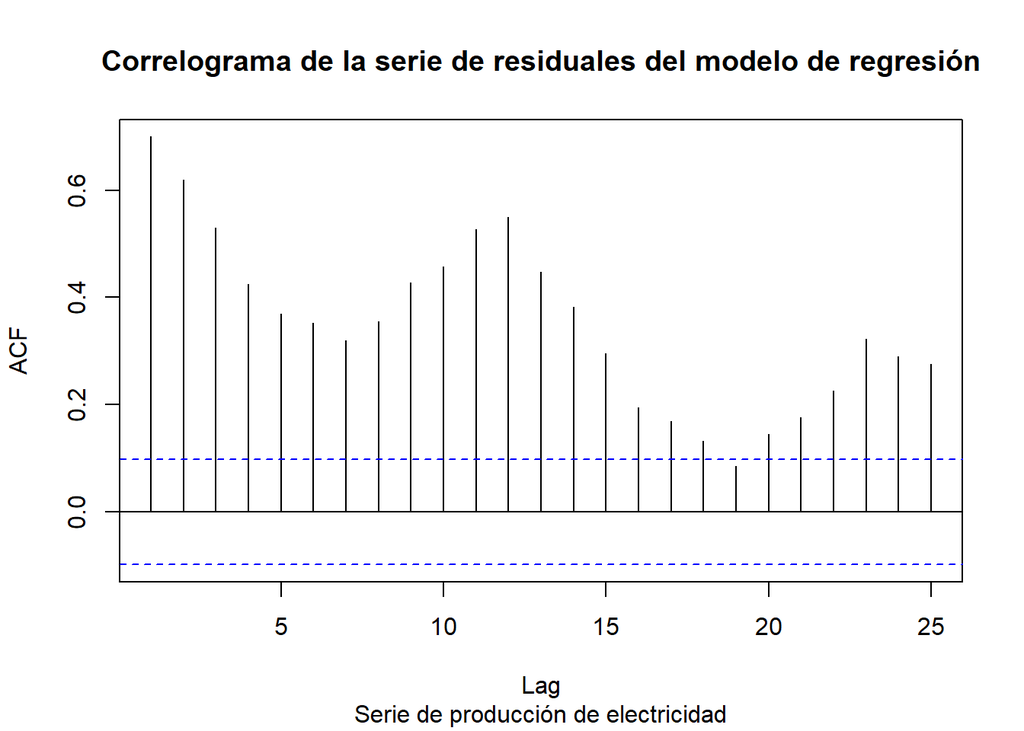

```r
#

Time <- 1:length(Elec.ts)
Imth <- cycle(Elec.ts)
Elec.lm <- lm(log(Elec.ts) ~ Time + I(Time^2) + factor(Imth))

#

acf(resid(Elec.lm), main = "")
title(main = "Correlograma de la serie de residuales del modelo de regresión",
      sub = "Serie de producción de electricidad")
```

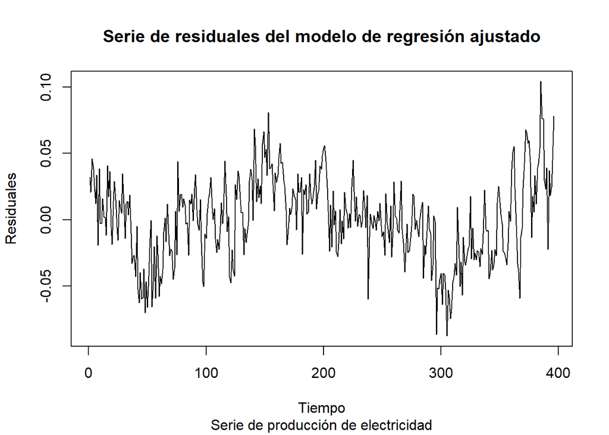

```r
#

plot(resid(Elec.lm), type = "l", main = "", xlab = "", ylab = "")
title(main = "Serie de residuales del modelo de regresión ajustado",
      sub = "Serie de producción de electricidad",
      xlab = "Tiempo",
      ylab = "Residuales")
```

```r
###

# Código para encontrar el mejor modelo ARMA(p, q) considerando el AIC
# (Akaike Information Criterion)

best.order <- c(0, 0, 0)
best.aic <- Inf
for(i in 0:2)for(j in 0:2){
  model <- arima(resid(Elec.lm), order = c(i, 0, j))
  fit.aic <- AIC(model)
  if(fit.aic < best.aic){
    best.order <- c(i, 0, j)
    best.arma <- arima(resid(Elec.lm), order = best.order)
    best.aic <- fit.aic
  }
}

best.order
```

```
[1] 2 0 0
```

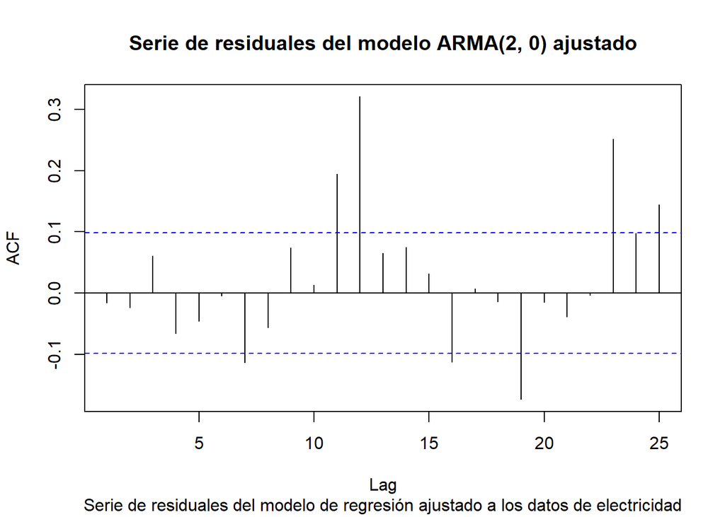

```r
#

acf(resid(best.arma), main = "")
title(main = "Serie de residuales del modelo ARMA(2, 0) ajustado",
      sub = "Serie de residuales del modelo de regresión ajustado a los datos de electricidad")
```

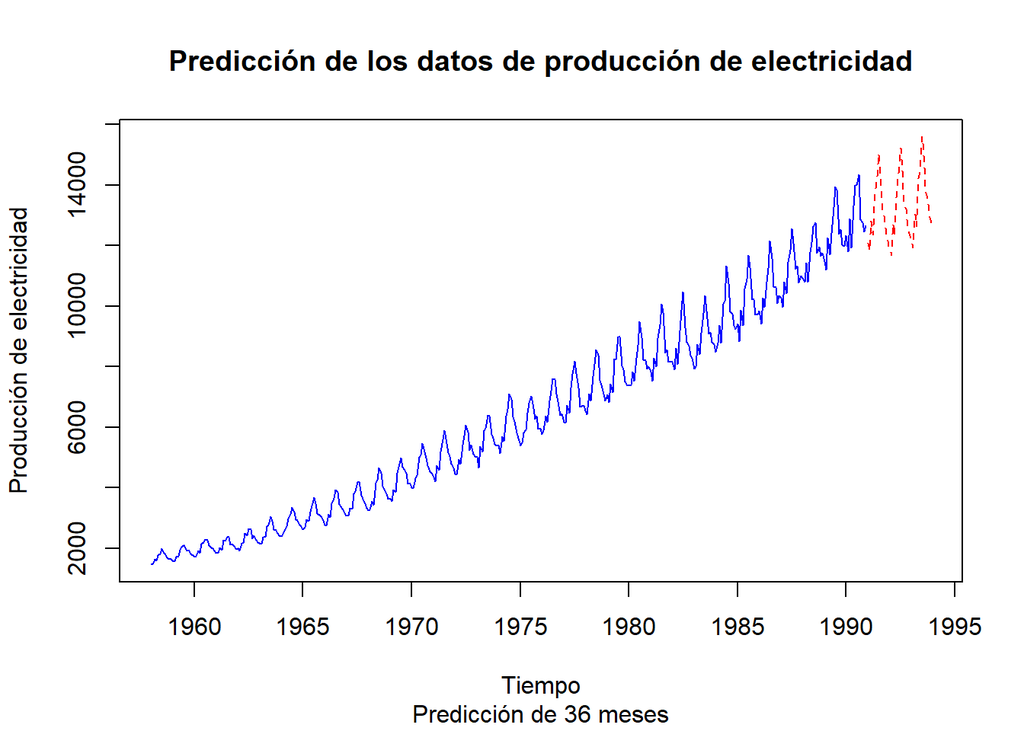

```r
###

new.time <- seq(length(Elec.ts)+1, length = 36)
new.data <- data.frame(Time = new.time, Imth = rep(1:12, 3))
predict.lm <- predict(Elec.lm, new.data)
predict.arma <- predict(best.arma, n.ahead = 36)
elec.pred <- ts(exp(predict.lm + predict.arma$pred), start = 1991, freq = 12)

#

ts.plot(cbind(Elec.ts, elec.pred), lty = 1:2,
        col = c("blue", "red"), xlab = "Tiempo",
        ylab = "Producción de electricidad",
        main = "Predicción de los datos de producción de electricidad",
        sub = "Predicción de 36 meses")
```

# RETO 1. PROCESO AR

## OBJETIVO

Observar algunas características de una serie de tiempo que proviene de un proceso AR(1) y ajustar un modelo.

## DESARROLLO

Reto 1. Simulación de un proceso AR(1)

Simula un proceso AR(1) de la forma $x[t] = 0.5 * x[t-1] + w[t]$ para $t = 1, 2, ..., 200$ y muestra gráficamente la serie de tiempo obtenida

Obtén el correlograma y el correlograma parcial del proceso AR(1) simulado

Ajusta un modelo autorregresivo a la serie simulada utilizando la función $ar$, observa el orden del modelo y el parámetro estimado (los parámetros estimados)

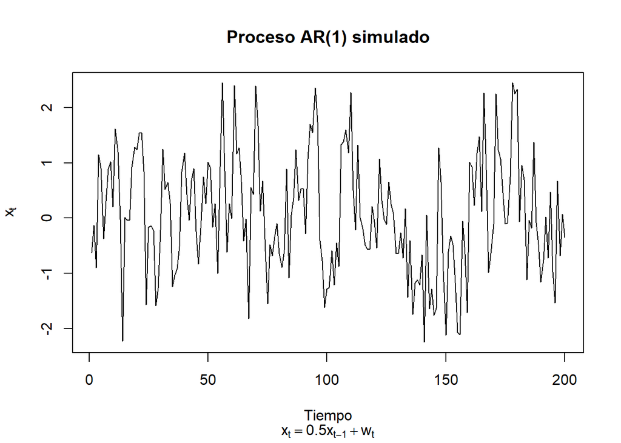

```r
# Reto 1. Proceso AR(1)

# 1. Simule un proceso AR(1) de la forma x[t] = 0.5 * x[t-1] + w[t] para
# t = 1, 2, ..., 200 y muestre gráficamente la serie de tiempo obtenida

# 2. Obtenga el correlograma y el correlograma parcial del proceso AR(1)
# simulado

# 3. Ajuste un modelo autorregresivo a la serie simulada utilizando la
# función ar, observe el orden del módelo y el parámetro
# estimado (los paramétros estimados)

# **Solución**

# Simulación en R

# Un proceso AR(1) puede ser simulado en R como sigue:

set.seed(1)
x <- w <- rnorm(200)
for(t in 2:200) x[t] <- 0.5 * x[t-1] + w[t]
plot(x, type = "l", xlab = "", ylab = "")
title(main = "Proceso AR(1) simulado",
      xlab = "Tiempo",
      ylab = expression(x[t]),
      sub = expression(x[t]==0.5*x[t-1]+w[t]))
```

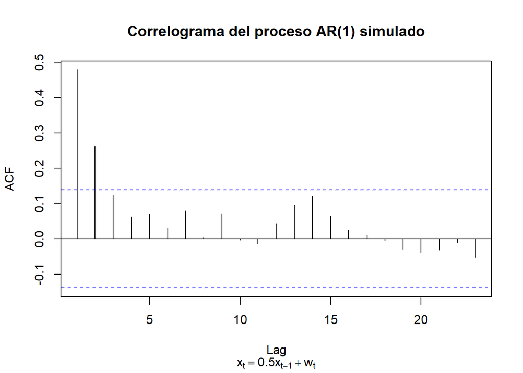

```r
#

acf(x, main = "")
title(main = "Correlograma del proceso AR(1) simulado",
      sub = expression(x[t]==0.5*x[t-1]+w[t]))
```

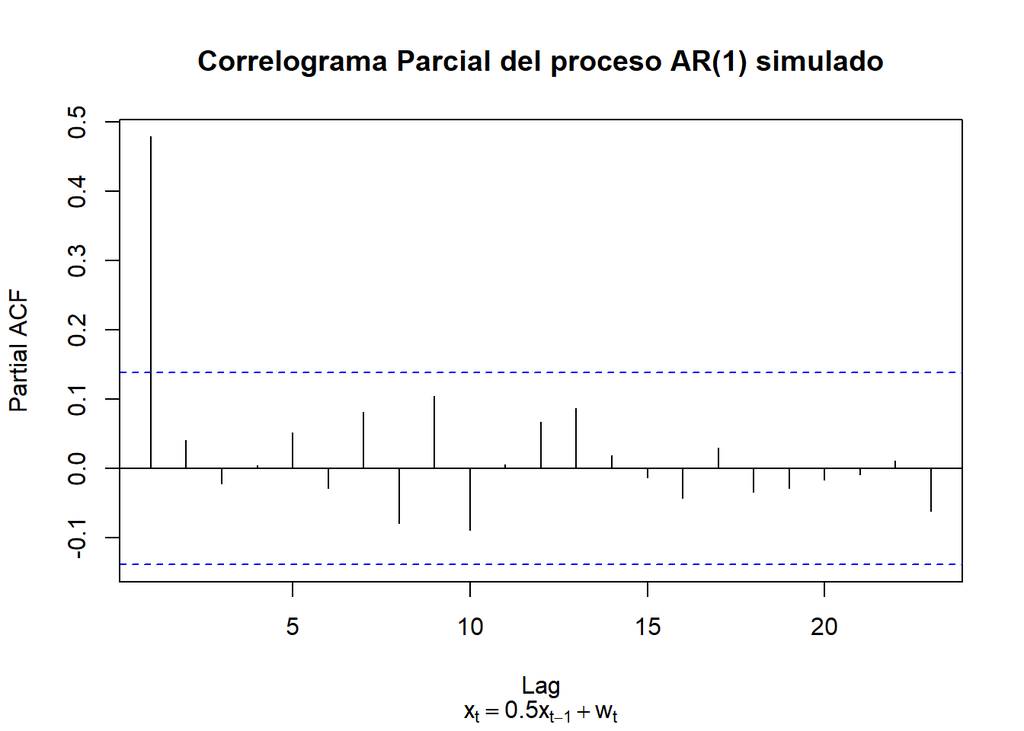

```r
#

pacf(x, main = "")
title(main = "Correlograma Parcial del proceso AR(1) simulado",
      sub = expression(x[t]==0.5*x[t-1]+w[t]))
```

```r
###

# Modelos Ajustados

# Ajuste de modelos a series simuladas

x.ar <- ar(x, method = "mle")
x.ar$order
```

```
[1] 1
```

```r
x.ar$ar
```

```
[1] 0.4782263
```